# Analyzing Individual BGG Users

Phil Henrickson

2021-12-31

# **betoqp’s** BoardGameGeek Collection

This notebook contains a set of analyses for the selected user’s boardgamegeek collection. The bulk of the analysis is focused on building a user-specific predictive model to predict the games that betoqp is likely to own. This enables to ask questions like, based on the games the user currently owns, what games are a good fit for their collection? What upcoming games are they likely to purchase?

This analysis is based on data from BoardGameGeek that was last updated on **2021-12-20.**

# 1 Collection Overview

We can look at a basic description of the number of games that the user owns, has rated, has previously owned, etc.

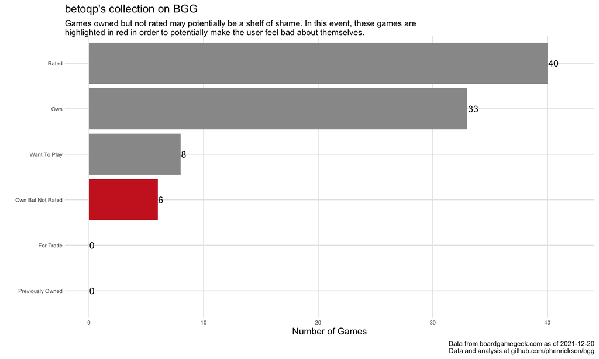

What years has the user owned/rated games from? While we can’t see when a user added or removed a game from their collection, we can look at their collection by the years in which their games were published.

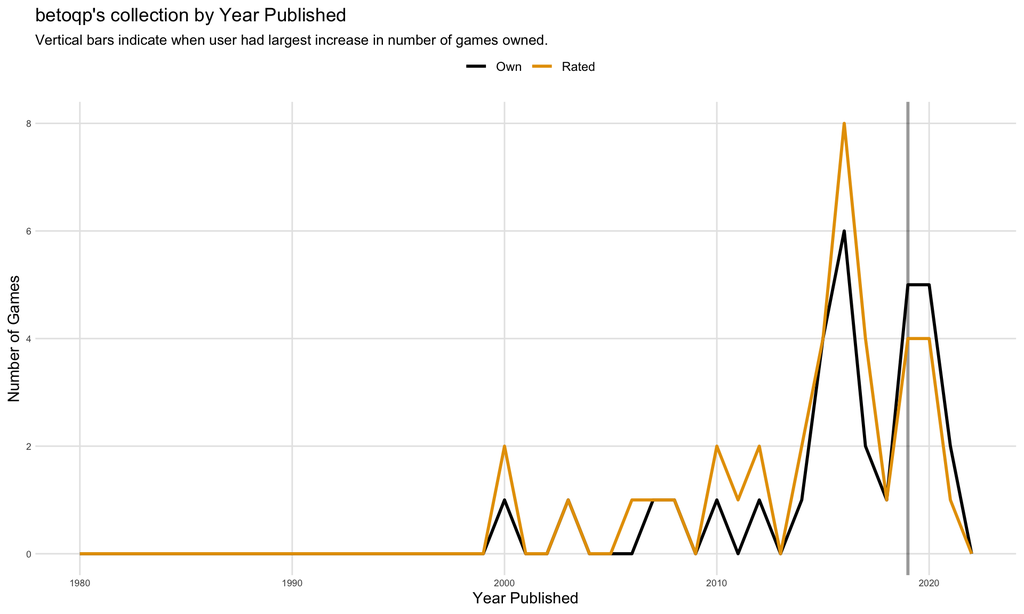

## 1.1 What types of games does betoqp own?

We can look at the most frequent types of categories, mechanics, designers, and artists that appear in a user’s collection.

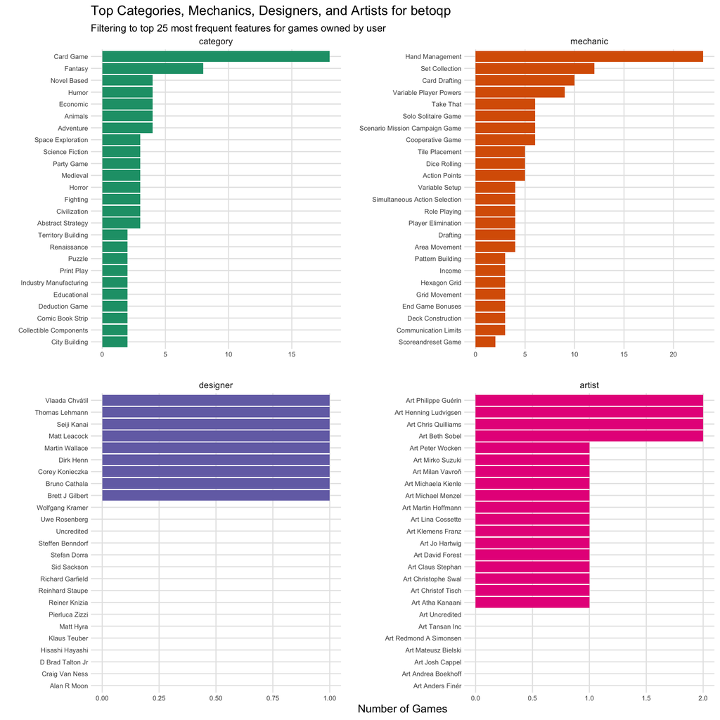

# 2 Modeling **betoqp’s** Collection

| username | dataset | period | games_owned | games_rated | games_played |
| --- | --- | --- | --- | --- | --- |
| betoqp | training | published before 2020 | 24 | 35 | 36 |
| betoqp | test | published 2020 or later | 7 | 5 | 8 |

There are two main (binary) outcomes we will be modeling for the user.

The first, **own** refers to whether the user currently lists a game as owned in their collection. The second, **played** refers to whether the user currently owns, has rated, or previously owned a game. This means the latter will generally have a larger list of games, but may still be a useful category to examine for people who play lots of games without necessarily owning them.

We will train predictive models to learn the probability that the user will own or play individual games based on their features.

## 2.1 Coefficients for betoqp

We can examine coefficients from the trained modes, which are penalized logistic regressions fit to our two main outcomes. Positive values indicate that a feature increases a user’s probabilility of owning/rating a game, while negative values indicate a feature decreases the probability.

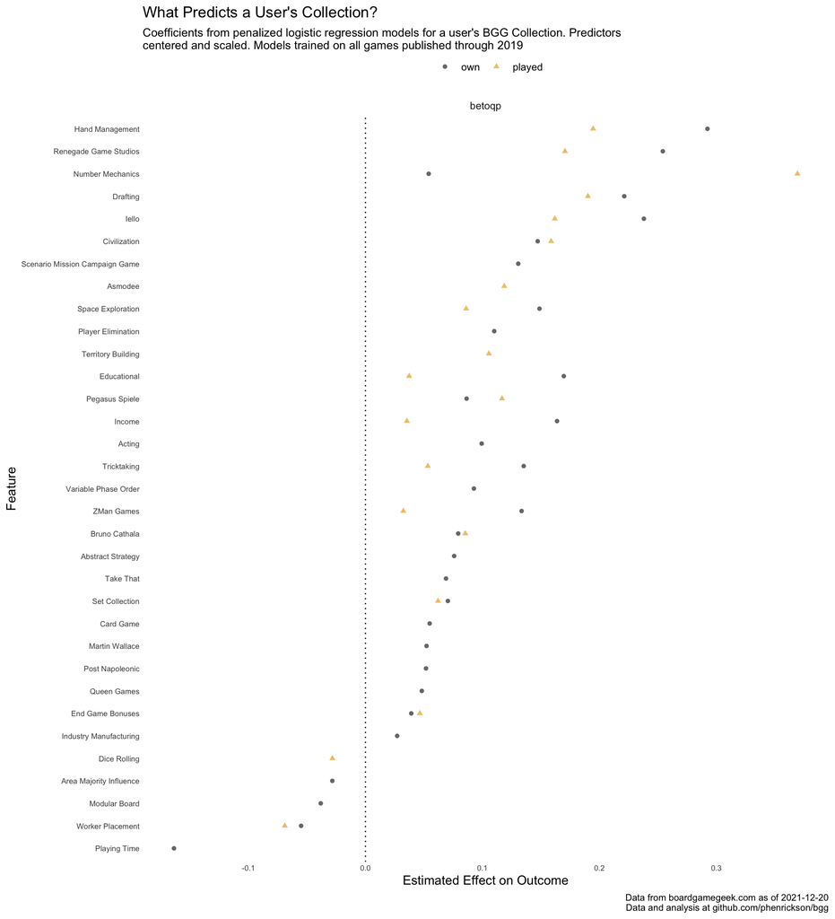

## 2.2 Visualizing Predictors for betoqp’s Collection

Why did the model identify these features? We can make density plots of the important features for predicting whether the user owned a game. Blue indicates the density for games owned by the user, while grey indicates the density for games not owned by the user.

[figure not shown]

Binary predictors can be difficult to see with this visualization, so we can also directly examine the percentage of games in a user’s collection with a predictor vs the percentage of all games with that predictor.

| username | Feature | % of Games with Feature In_Collection | % of Games with Feature All_Games | Ratio |
| --- | --- | --- | --- | --- |
| betoqp | Income | 12.5% | 0.7% | 17.8 |
| betoqp | Drafting | 16.7% | 1.0% | 16.5 |
| betoqp | Renegade Game Studios | 12.5% | 0.9% | 14.5 |
| betoqp | End Game Bonuses | 12.5% | 1.3% | 9.9 |
| betoqp | Space Exploration | 12.5% | 1.7% | 7.5 |
| betoqp | Iello | 16.7% | 3.1% | 5.3 |
| betoqp | Educational | 8.3% | 1.6% | 5.2 |
| betoqp | Tricktaking | 8.3% | 1.7% | 5.0 |
| betoqp | Civilization | 12.5% | 2.7% | 4.7 |
| betoqp | Post Napoleonic | 4.2% | 0.9% | 4.6 |
| betoqp | Variable Phase Order | 8.3% | 2.1% | 4.0 |
| betoqp | Acting | 4.2% | 1.1% | 3.9 |
| betoqp | ZMan Games | 12.5% | 3.5% | 3.5 |
| betoqp | Scenario Mission Campaign Game | 8.3% | 2.4% | 3.5 |
| betoqp | Pegasus Spiele | 16.7% | 4.8% | 3.5 |
| betoqp | Player Elimination | 12.5% | 4.0% | 3.1 |
| betoqp | Take That | 20.8% | 6.7% | 3.1 |
| betoqp | Queen Games | 4.2% | 1.4% | 2.9 |
| betoqp | Hand Management | 62.5% | 26.7% | 2.3 |
| betoqp | Set Collection | 37.5% | 17.6% | 2.1 |
| betoqp | Abstract Strategy | 12.5% | 6.3% | 2.0 |
| betoqp | Card Game | 54.2% | 31.0% | 1.7 |
| betoqp | Area Majority Influence | 4.2% | 11.1% | 0.4 |
| betoqp | Worker Placement | 0.0% | 6.0% | 0.0 |
| betoqp | Modular Board | 0.0% | 11.0% | 0.0 |

# 3 Assess Model’s Performance on Training Set

Before predicting games in upcoming years, we can examine how well the model did and what games it liked in the training set. In this case, we used resampling techniques (cross validation) to ensure that the model had not seen a game before making its predictions.

## 3.1 Separation Plot

An easy way to examine the performance of classification model is to view a separation plot. We plot the predicted probabilities from the model for every game (from resampling) from lowest to highest. We then overlay a blue line for any game that the user does own. A good classifier is one that is able to *separate* the blue (games owned by the user) from the white (games not owned by the user), with most of the blue occurring at the highest probabilities (right side of the chart).

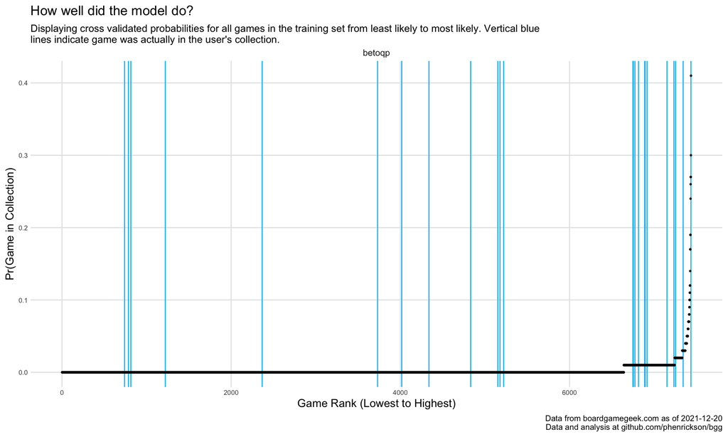

## 3.2 Top Games for **betoqp** from Training Set

We can display this information in table form, displaying the 100 games with the highest probability of ownership, adding a blue line when the user does own the game.

| username | yearpublished | game_id | name | pred_played | pred_own | actual_played | actual_own |
| --- | --- | --- | --- | --- | --- | --- | --- |
| betoqp | 2014 | 163412 | Patchwork | 0.04 | 0.41 | 0 | 0 |
| betoqp | 2016 | 167791 | Terraforming Mars | 0.17 | 0.30 | 1 | 1 |
| betoqp | 2019 | 270971 | Era: Medieval Age | 0.28 | 0.27 | 0 | 0 |
| betoqp | 2007 | 28720 | Brass: Lancashire | 0.02 | 0.27 | 0 | 0 |
| betoqp | 2019 | 281259 | The Isle of Cats | 0.09 | 0.26 | 0 | 0 |
| betoqp | 2018 | 244711 | Newton | 0.15 | 0.24 | 0 | 0 |
| betoqp | 2017 | 228341 | Pulsar 2849 | 0.25 | 0.19 | 0 | 0 |
| betoqp | 2019 | 266507 | Clank!: Legacy – Acquisitions Incorporated | 0.40 | 0.19 | 0 | 0 |
| betoqp | 2016 | 72321 | The Networks | 0.07 | 0.17 | 0 | 0 |
| betoqp | 2019 | 271324 | It's a Wonderful World | 0.21 | 0.17 | 0 | 0 |
| betoqp | 2018 | 247763 | Underwater Cities | 0.03 | 0.14 | 0 | 0 |
| betoqp | 2015 | 181161 | Brick Party | 0.05 | 0.12 | 0 | 0 |
| betoqp | 2018 | 205896 | Rising Sun | 0.49 | 0.12 | 0 | 0 |
| betoqp | 2019 | 276025 | Maracaibo | 0.15 | 0.11 | 0 | 0 |
| betoqp | 2019 | 260710 | Amul | 0.12 | 0.11 | 0 | 0 |
| betoqp | 2011 | 84419 | Space Empires: 4X | 0.04 | 0.10 | 0 | 0 |
| betoqp | 2017 | 220308 | Gaia Project | 0.12 | 0.10 | 0 | 0 |
| betoqp | 2016 | 207336 | Honshū | 0.09 | 0.10 | 0 | 0 |
| betoqp | 2012 | 120677 | Terra Mystica | 0.13 | 0.09 | 0 | 0 |
| betoqp | 2015 | 171273 | FUSE | 0.10 | 0.09 | 0 | 0 |
| betoqp | 2014 | 154203 | Imperial Settlers | 0.12 | 0.08 | 0 | 0 |
| betoqp | 2014 | 136594 | Dragon's Hoard | 0.01 | 0.08 | 0 | 0 |
| betoqp | 2014 | 146886 | La Granja | 0.05 | 0.08 | 0 | 0 |
| betoqp | 2019 | 283863 | The Magnificent | 0.22 | 0.07 | 0 | 0 |
| betoqp | 2011 | 68425 | Eminent Domain | 0.02 | 0.07 | 0 | 0 |
| betoqp | 2016 | 198525 | Lotus | 0.01 | 0.07 | 0 | 0 |
| betoqp | 2016 | 198190 | Kepler-3042 | 0.03 | 0.07 | 0 | 0 |
| betoqp | 2010 | 68448 | 7 Wonders | 0.09 | 0.07 | 1 | 0 |
| betoqp | 2013 | 144239 | Impulse | 0.03 | 0.07 | 0 | 0 |
| betoqp | 2017 | 223740 | Bargain Quest | 0.03 | 0.07 | 0 | 0 |

[output cut: 70 more lines]

We can also more formally assess how well the model did in resampling by looking at the area under the receiver operating characteristic. A perfect model would receive a score of 1, while a model that cannot predict the outcome will default to a score of 0.5. The extent to which something is a *good* score depends on the setting, but generally anything in the .8 to .9 range is very good while the .7 to .8 range is perfectly acceptable.

| username | outcome_type | .metric | .estimator | .estimate |
| --- | --- | --- | --- | --- |
| betoqp | own | roc_auc | binary | 0.737 |
| betoqp | played | roc_auc | binary | 0.794 |

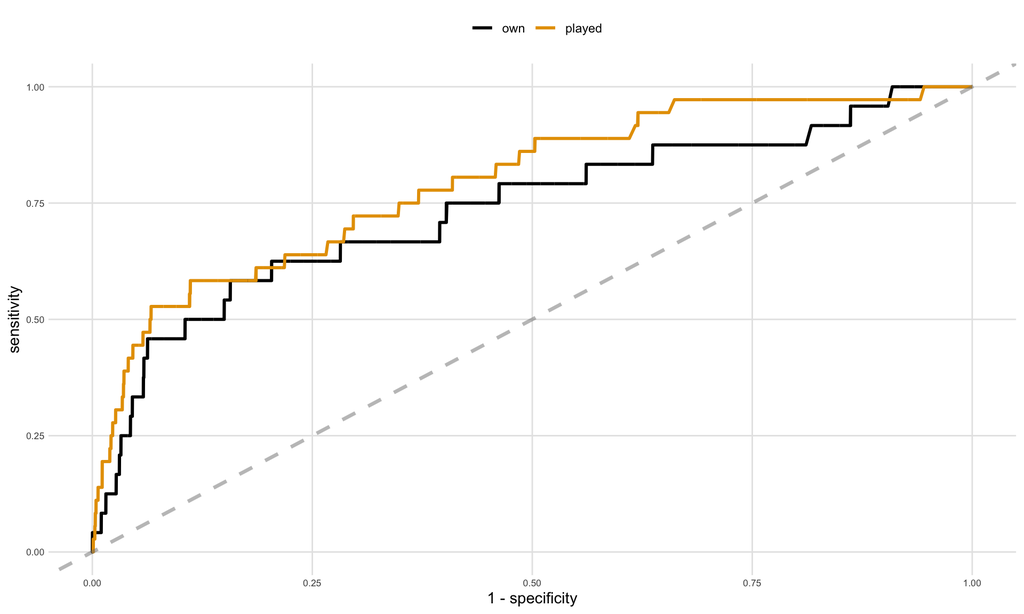

Another way to think about the model performance is to view its lift, or its ability to detect the positive outcomes over that of a null model. High lift indicates the model can much more quickly find all of the positive outcomes (in this case, games owned or played by the user), while a model with no lift is no better than random guessing.

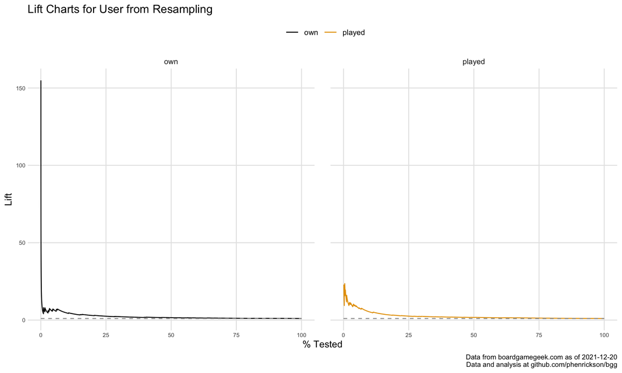

## 3.3 Most and Least Likely Games

What games does the model think betoqp is **most likely to own** that are **not** in their collection?

| username | yearpublished | game_id | name | pred_own | actual_own |
| --- | --- | --- | --- | --- | --- |
| betoqp | 2014 | 163412 | Patchwork | 0.41 | 0 |
| betoqp | 2019 | 270971 | Era: Medieval Age | 0.27 | 0 |
| betoqp | 2007 | 28720 | Brass: Lancashire | 0.27 | 0 |
| betoqp | 2019 | 281259 | The Isle of Cats | 0.26 | 0 |
| betoqp | 2018 | 244711 | Newton | 0.24 | 0 |

What games does the model think betoqp is **least likely to own** that **are** in their collection?

| username | yearpublished | game_id | name | pred_own | actual_own |
| --- | --- | --- | --- | --- | --- |
| betoqp | 2000 | 2655 | Hive | 0 | 1 |
| betoqp | 2014 | 160477 | Onitama | 0 | 1 |
| betoqp | 2019 | 264241 | Mandala | 0 | 1 |
| betoqp | 2012 | 127398 | Legends of Andor | 0 | 1 |
| betoqp | 2016 | 192153 | Pandemic: Reign of Cthulhu | 0 | 1 |

## 3.4 Top Games by Year

Top 25 games most likely to be owned by the user in each year, highlighting in blue the games that the user has owned/played.

| rank | 2011 | 2012 | 2013 | 2014 | 2015 | 2016 | 2017 | 2018 | 2019 |
| --- | --- | --- | --- | --- | --- | --- | --- | --- | --- |
| 1 | Space Empires: 4X | Terra Mystica | Impulse | Patchwork | Brick Party | Terraforming Mars | Pulsar 2849 | Newton | Era: Medieval Age |
| 2 | Eminent Domain | Pax Porfiriana | The Doom That Came to Atlantic City | Imperial Settlers | FUSE | The Networks | Gaia Project | Underwater Cities | The Isle of Cats |
| 3 | Octopus's Garden | Seasons | UGO! | Dragon's Hoard | Bullfrogs | Honshū | Bargain Quest | Rising Sun | Clank!: Legacy – Acquisitions Incorporated |
| 4 | Eclipse | Smash Up | Friese's Landlord | La Granja | The Pursuit of Happiness | Lotus | Topiary | Duelosaur Island | It's a Wonderful World |
| 5 | Pastiche | The Manhattan Project | Smash Up: The Obligatory Cthulhu Set | Roll for the Galaxy | Nevermore | Kepler-3042 | Bunny Kingdom | Everdell | Maracaibo |
| 6 | Ninjato | Uchronia | Hanamikoji | Evolution | Raiders of the North Sea | Smash Up: It's Your Fault! | Ex Libris | Gunkimono | Amul |
| 7 | Discworld: Ankh-Morpork | Neuroshima: Convoy | Tash-Kalar: Arena of Legends | Saint Petersburg (Second Edition) | Arboretum | Kanagawa | Pocket Mars | Architects of the West Kingdom | The Magnificent |
| 8 | Old Men of the Forest | Kairo | Goblins Drool, Fairies Rule! | Sheriff of Nottingham | 504 | Apotheca | Moons | Prowler's Passage | Time Chase |
| 9 | Trajan | Kill the Overlord | Smash Up: Awesome Level 9000 | Smash Up: Science Fiction Double Feature | Exploding Kittens: NSFW Deck | Sushi Go Party! | Smash Up: What Were We Thinking? | Shards of Infinity | Circadians: First Light |
| 10 | Principato | The Hobbit Card Game | Agent Hunter | Fields of Arle | Smash Up: Pretty Pretty Smash Up | Tales & Games: The Pied Piper | Clank! In! Space!: A Deck-Building Adventure | Franchise | Eternal: Chronicles of the Throne |
| 11 | Dungeon Petz | Rent a Hero | Longhorn | Haru Ichiban | 7 Wonders Duel | 13 Days: The Cuban Missile Crisis | Sentient | Smash Up: That '70s Expansion | Yukon Airways |
| 12 | Feudalia | Agricola: All Creatures Big and Small | Titanium Wars | Five Tribes | Star Realms: Colony Wars | Hero Realms | Queendomino | Wonderland | Old West Empresario |
| 13 | Ascending Empires | Morels | The Witches: A Discworld Game | Abyss | Blood Rage | Capital Lux | Alien Artifacts | Reykholt | Imperial Settlers: Roll & Write |
| 14 | Spectral Rails | Polis: Fight for the Hegemony | Theseus: The Dark Orbit | Alchemists | Risk: Europe | Agricola (Revised Edition) | The Fox in the Forest | Lift Off | Tapestry |
| 15 | Ultimate Warriorz | Okiya | Legacy: The Testament of Duke de Crecy | Chimera | Smash Up: Munchkin | Citadels | Scott Pilgrim's Precious Little Card Game | The Little Flower Shop | Revolution of 1828 |
| 16 | Timeline: Discoveries | Tzolk'in: The Mayan Calendar | Steam Park | Shipwrights of the North Sea | Kitty Paw | Evolution: Climate | Castles of Caladale | Sprawlopolis | Watergate |
| 17 | Rory's Story Cubes: Voyages | Doctor Who: The Card Game | Sail to India | Onward to Venus | Qwirkle Cards | The Oregon Trail Card Game | A Handful of Stars | Muse: Awakenings | Paris: La Cité de la Lumière |
| 18 | Munchkin Zombies | Clash of Cultures | Prosperity | Wir sind das Volk! | Best Treehouse Ever | Junk Art | Fireworks | Spell Smashers | Nanty Narking |
| 19 | New York | Waka Waka | Castle Dice | Akrotiri | The Voyages of Marco Polo | Conan | Exploding Kittens: Party Pack | Hokkaido | Aquatica |
| 20 | Dungeon Fighter | Uncharted: The Board Game | Guildhall: Job Faire | Smash Up: Monster Smash | Cat Tower | Shiba Inu House | Dungeon Draft | Smash Up: Oops, You Did It Again | Noctiluca |
| 21 | A Game of Thrones: The Board Game (Second Edition) | Mythic Battles | Gravwell: Escape from the 9th Dimension | Star Realms | Exploding Kittens | Covert | Unfair | Fort Sumter: The Secession Crisis, 1860-61 | Barrage |
| 22 | Skull | Guildhall | 8 Masters' Revenge | Onirim (Second Edition) | Die Legenden von Andor: Chada & Thorn | Planet Defenders | Paper Tales | Liberation | HexRoller |
| 23 | Panic Station | Among the Stars | Thebes: The Tomb Raiders | Eminent Domain: Microcosm | Haleakala | World's Fair 1893 | Altiplano | Jurassic Snack | Chai |
| 24 | Pirate Fluxx | Plato 3000 | Boss Monster: The Dungeon Building Card Game | Castles of Mad King Ludwig | Holmes: Sherlock & Mycroft | Dokmus | Sundae Split | Barbarians: The Invasion | Power Rangers: Heroes of the Grid |
| 25 | King of Tokyo | Freedom: The Underground Railroad | Welcome to the Dungeon | Omega Centauri | Raptor | Dicey Goblins | Smash Up: Big in Japan | Castell | Crystal Palace |

## 3.5 Interactive Predictions from Resampling

Interactive table for predictions from resampling.

|  | username | yearpublished | rank | game_id | name | pred_played | pred_own | actual_played | actual_own |
| --- | --- | --- | --- | --- | --- | --- | --- | --- | --- |
| 1 | betoqp | 1900 | 234 | 11582 | Schnapsen | 0 | 0.01 | 0 | 0 |
| 2 | betoqp | 1900 | 346 | 4583 | Pinochle | 0 | 0.01 | 0 | 0 |
| 3 | betoqp | 1900 | 490 | 4505 | Tarot | 0 | 0.01 | 0 | 0 |
| 4 | betoqp | 1900 | 643 | 11670 | The Game of Authors | 0.01 | 0.01 | 0 | 0 |
| 5 | betoqp | 1900 | 657 | 10799 | Old Maid | 0 | 0.01 | 0 | 0 |
| 6 | betoqp | 1900 | 808 | 5546 | Marbles | 0 | 0 | 0 | 0 |
| 7 | betoqp | 1900 | 811 | 11901 | Tic-Tac-Toe | 0 | 0 | 0 | 0 |
| 8 | betoqp | 1900 | 861 | 188 | Go | 0 | 0 | 0 | 0 |
| 9 | betoqp | 1900 | 975 | 171 | Chess | 0 | 0 | 0 | 0 |
| 10 | betoqp | 1900 | 986 | 2065 | Shogi | 0 | 0 | 0 | 0 |

[output cut: 7426 more lines]

# 4 Validating the Model on 2020

How well did a model trained on a user’s collection through 2019 perform in predicting games for the user from 2020?

| username | outcome_type | yearpublished | .metric | .estimator | .estimate |
| --- | --- | --- | --- | --- | --- |
| betoqp | own | 2020 | roc_auc | binary | 0.818 |
| betoqp | played | 2020 | roc_auc | binary | 0.808 |

Table of top 25 games from 2020, highlighting games that the user owns.

| username | yearpublished | game_id | name | pred_own | pred_played | actual_own | actual_played |
| --- | --- | --- | --- | --- | --- | --- | --- |
| betoqp | 2020 | 184267 | On Mars | 0.50 | 0.57 | 0 | 0 |
| betoqp | 2020 | 307844 | Atheneum: Mystic Library | 0.19 | 0.15 | 0 | 0 |
| betoqp | 2020 | 246900 | Eclipse: Second Dawn for the Galaxy | 0.11 | 0.14 | 0 | 0 |
| betoqp | 2020 | 288169 | The Fox in the Forest Duet | 0.10 | 0.03 | 0 | 1 |
| betoqp | 2020 | 316377 | 7 Wonders (Second Edition) | 0.07 | 0.16 | 0 | 0 |
| betoqp | 2020 | 271002 | Myraclia | 0.06 | 0.09 | 0 | 0 |
| betoqp | 2020 | 297030 | Tekhenu: Obelisk of the Sun | 0.06 | 0.04 | 0 | 0 |
| betoqp | 2020 | 217990 | Stellar Horizons | 0.05 | 0.02 | 0 | 0 |
| betoqp | 2020 | 295577 | Dungeon Mayhem: Monster Madness | 0.05 | 0.01 | 0 | 0 |
| betoqp | 2020 | 299074 | Space Battle Lunchtime Card Game | 0.05 | 0.02 | 0 | 0 |
| betoqp | 2020 | 309862 | Gudetama: The Tricky Egg Card Game | 0.05 | 0.01 | 0 | 0 |
| betoqp | 2020 | 293556 | Gloomy Graves | 0.04 | 0.04 | 0 | 0 |
| betoqp | 2020 | 293678 | Stellar | 0.04 | 0.03 | 0 | 0 |
| betoqp | 2020 | 296151 | Viscounts of the West Kingdom | 0.04 | 0.08 | 0 | 0 |
| betoqp | 2020 | 302465 | Obsidia | 0.04 | 0.09 | 0 | 0 |
| betoqp | 2020 | 256317 | Guild Master | 0.03 | 0.06 | 0 | 0 |
| betoqp | 2020 | 300322 | Hallertau | 0.03 | 0.02 | 0 | 0 |
| betoqp | 2020 | 249275 | The Silver River | 0.02 | 0.04 | 0 | 0 |
| betoqp | 2020 | 279537 | The Search for Planet X | 0.02 | 0.03 | 0 | 0 |
| betoqp | 2020 | 281655 | High Frontier 4 All | 0.02 | 0.04 | 0 | 0 |
| betoqp | 2020 | 296237 | Warp's Edge | 0.02 | 0.01 | 0 | 0 |
| betoqp | 2020 | 297204 | Traintopia | 0.02 | 0.03 | 0 | 0 |
| betoqp | 2020 | 298017 | Treelings | 0.02 | 0.02 | 0 | 0 |
| betoqp | 2020 | 299372 | Succulent | 0.02 | 0.01 | 0 | 0 |
| betoqp | 2020 | 299960 | Alma Mater | 0.02 | 0.03 | 0 | 0 |

# 5 Predicting Upcoming Games (2020 and On) for **betoqp**

Examine the top games for the test set.

| username | yearpublished | game_id | name | rank | own | played |
| --- | --- | --- | --- | --- | --- | --- |
| betoqp | 2020 | 184267 | On Mars | 1 | 0.50 | 0.57 |
| betoqp | 2020 | 307844 | Atheneum: Mystic Library | 2 | 0.19 | 0.15 |
| betoqp | 2020 | 246900 | Eclipse: Second Dawn for the Galaxy | 3 | 0.11 | 0.14 |
| betoqp | 2020 | 288169 | The Fox in the Forest Duet | 4 | 0.10 | 0.03 |
| betoqp | 2020 | 316377 | 7 Wonders (Second Edition) | 5 | 0.07 | 0.16 |
| betoqp | 2020 | 271002 | Myraclia | 6 | 0.06 | 0.09 |
| betoqp | 2020 | 297030 | Tekhenu: Obelisk of the Sun | 7 | 0.06 | 0.04 |
| betoqp | 2020 | 299074 | Space Battle Lunchtime Card Game | 8 | 0.05 | 0.02 |
| betoqp | 2020 | 295577 | Dungeon Mayhem: Monster Madness | 9 | 0.05 | 0.01 |
| betoqp | 2020 | 217990 | Stellar Horizons | 10 | 0.05 | 0.02 |
| betoqp | 2020 | 309862 | Gudetama: The Tricky Egg Card Game | 11 | 0.05 | 0.01 |
| betoqp | 2020 | 302465 | Obsidia | 12 | 0.04 | 0.09 |
| betoqp | 2020 | 293556 | Gloomy Graves | 13 | 0.04 | 0.04 |
| betoqp | 2020 | 296151 | Viscounts of the West Kingdom | 14 | 0.04 | 0.08 |
| betoqp | 2020 | 293678 | Stellar | 15 | 0.04 | 0.03 |
| betoqp | 2020 | 300322 | Hallertau | 16 | 0.03 | 0.02 |
| betoqp | 2020 | 256317 | Guild Master | 17 | 0.03 | 0.06 |
| betoqp | 2020 | 315138 | Autumn Harvest: A Tea Dragon Society Game | 18 | 0.02 | 0.01 |
| betoqp | 2020 | 249275 | The Silver River | 19 | 0.02 | 0.04 |
| betoqp | 2020 | 325635 | Unmatched: Little Red Riding Hood vs. Beowulf | 20 | 0.02 | 0.02 |
| betoqp | 2020 | 296237 | Warp's Edge | 21 | 0.02 | 0.01 |
| betoqp | 2020 | 281655 | High Frontier 4 All | 22 | 0.02 | 0.04 |
| betoqp | 2020 | 297204 | Traintopia | 23 | 0.02 | 0.03 |
| betoqp | 2020 | 299960 | Alma Mater | 24 | 0.02 | 0.03 |
| betoqp | 2020 | 298017 | Treelings | 25 | 0.02 | 0.02 |
| betoqp | 2021 | 309319 | Apogee | 1 | 0.10 | 0.02 |
| betoqp | 2021 | 333553 | For the King (and Me) | 2 | 0.10 | 0.10 |
| betoqp | 2021 | 315624 | World Changers | 3 | 0.07 | 0.03 |
| betoqp | 2021 | 310873 | Carnegie | 4 | 0.04 | 0.06 |
| betoqp | 2021 | 324856 | The Crew: Mission Deep Sea | 5 | 0.04 | 0.01 |
| betoqp | 2021 | 332420 | NEXUM: Galaxy | 6 | 0.04 | 0.06 |
| betoqp | 2021 | 291859 | Riftforce | 7 | 0.03 | 0.08 |
| betoqp | 2021 | 299684 | Khôra: Rise of an Empire | 8 | 0.03 | 0.01 |
| betoqp | 2021 | 304783 | Hadrian's Wall | 9 | 0.03 | 0.02 |
| betoqp | 2021 | 339906 | The Hunger | 10 | 0.03 | 0.01 |
| betoqp | 2021 | 343905 | Boonlake | 11 | 0.03 | 0.12 |
| betoqp | 2021 | 252752 | Genotype: A Mendelian Genetics Game | 12 | 0.03 | 0.04 |
| betoqp | 2021 | 295947 | Cascadia | 13 | 0.02 | 0.02 |
| betoqp | 2021 | 324957 | The Snallygaster Situation: Kids on Bikes Board Game | 14 | 0.02 | 0.02 |
| betoqp | 2021 | 315221 | Vampire: The Masquerade – Rivals Expandable Card Game | 15 | 0.02 | 0.01 |
| betoqp | 2021 | 299450 | Tsukuyumi: Full Moon Down (Second Edition) | 16 | 0.02 | 0.02 |
| betoqp | 2021 | 337961 | Transformers Deck-Building Game | 17 | 0.02 | 0.01 |
| betoqp | 2021 | 343526 | G.I. JOE Deck-Building Game | 18 | 0.02 | 0.01 |
| betoqp | 2021 | 328871 | Terraforming Mars: Ares Expedition | 19 | 0.02 | 0.01 |
| betoqp | 2021 | 295535 | Dark Ages: Heritage of Charlemagne | 20 | 0.02 | 0.05 |
| betoqp | 2021 | 304985 | Dark Ages: Holy Roman Empire | 21 | 0.02 | 0.05 |
| betoqp | 2021 | 304666 | Wild Life: The Card Game | 22 | 0.02 | 0.01 |
| betoqp | 2021 | 337765 | Brian Boru: High King of Ireland | 23 | 0.02 | 0.04 |
| betoqp | 2021 | 319999 | Dungeon Decorators | 24 | 0.02 | 0.09 |
| betoqp | 2021 | 298309 | Winter Queen | 25 | 0.02 | 0.02 |
| betoqp | 2022 | 330950 | Age of Galaxy | 1 | 0.06 | 0.04 |
| betoqp | 2022 | 334065 | Verdant | 2 | 0.06 | 0.09 |
| betoqp | 2022 | 299106 | Fractal: Beyond the Void | 3 | 0.03 | 0.06 |
| betoqp | 2022 | 295895 | Distilled | 4 | 0.02 | 0.01 |
| betoqp | 2022 | 254632 | Hyperspace | 5 | 0.01 | 0.01 |
| betoqp | 2022 | 342444 | Black Rose Wars: Rebirth | 6 | 0.01 | 0.01 |
| betoqp | 2022 | 321608 | Hegemony: Lead Your Class to Victory | 7 | 0.01 | 0.01 |
| betoqp | 2022 | 242705 | Aeon Trespass: Odyssey | 8 | 0.01 | 0.01 |
| betoqp | 2022 | 284189 | Foundations of Rome | 9 | 0.01 | 0.00 |
| betoqp | 2022 | 325494 | ISS Vanguard | 10 | 0.01 | 0.01 |
| betoqp | 2022 | 254127 | Europa Universalis: The Price of Power | 11 | 0.01 | 0.02 |
| betoqp | 2022 | 317511 | Tindaya | 12 | 0.01 | 0.07 |
| betoqp | 2022 | 328866 | My Father's Work | 13 | 0.01 | 0.01 |
| betoqp | 2022 | 281647 | Stellaris: Infinite Legacy | 14 | 0.01 | 0.04 |
| betoqp | 2022 | 348463 | ECO: Coral Reef | 15 | 0.01 | 0.01 |
| betoqp | 2022 | 318450 | Bios: Mesofauna | 16 | 0.00 | 0.00 |
| betoqp | 2022 | 313807 | Oros | 17 | 0.00 | 0.00 |
| betoqp | 2022 | 276182 | Dead Reckoning | 18 | 0.00 | 0.01 |
| betoqp | 2022 | 322354 | DEFCON 1 | 19 | 0.00 | 0.00 |
| betoqp | 2022 | 312512 | The Transcontinental | 20 | 0.00 | 0.00 |
| betoqp | 2022 | 252315 | The Everrain | 21 | 0.00 | 0.00 |
| betoqp | 2022 | 219650 | Arydia: The Paths We Dare Tread | 22 | 0.00 | 0.00 |
| betoqp | 2022 | 312859 | Townsfolk Tussle | 23 | 0.00 | 0.00 |
| betoqp | 2022 | 237179 | Weather Machine | 24 | 0.00 | 0.00 |
| betoqp | 2022 | 274471 | Malhya: Lands of Legends | 25 | 0.00 | 0.01 |

## 5.1 Interactive Table for Upcoming Games 2020 and On

|  | username | yearpublished | game_id | name | rank | own | played |
| --- | --- | --- | --- | --- | --- | --- | --- |
| 1 | betoqp | 2020 | 184267 | On Mars | 1 | 0.5 | 0.57 |
| 2 | betoqp | 2020 | 307844 | Atheneum: Mystic Library | 2 | 0.19 | 0.15 |
| 3 | betoqp | 2020 | 246900 | Eclipse: Second Dawn for the Galaxy | 3 | 0.11 | 0.14 |
| 4 | betoqp | 2020 | 288169 | The Fox in the Forest Duet | 4 | 0.1 | 0.03 |
| 5 | betoqp | 2021 | 309319 | Apogee | 5 | 0.1 | 0.02 |
| 6 | betoqp | 2021 | 333553 | For the King (and Me) | 6 | 0.1 | 0.1 |
| 7 | betoqp | 2020 | 316377 | 7 Wonders (Second Edition) | 7 | 0.07 | 0.16 |
| 8 | betoqp | 2021 | 315624 | World Changers | 8 | 0.07 | 0.03 |
| 9 | betoqp | 2020 | 271002 | Myraclia | 9 | 0.06 | 0.09 |
| 10 | betoqp | 2022 | 330950 | Age of Galaxy | 10 | 0.06 | 0.04 |

[output cut: 1627 more lines]